# IterativeOcc

knecmab

Sunday, February 22, 2015

# 1 Introduction

# 2 Required input

The following packages are required:

```r
require(doParallel)
require(kernlab)
require(pROC)

require(iterOneClass)
require(rasterTiled)
```

And a list of settings:

```r
baseDir <- "D:/github/iterOneClass/demo/results"
iocc_settings <- list(nTrainUn = 100,
                 iterMax = "noChange+3",
                 indepUn = 0.5,
                 kFolds = 10,
                 seed = 123,
                 baseDir = baseDir,
                 nPixelsPerTile = 10000,
                 expand = 3,
                 minPppAtLw=TRUE)
```

Finally, some data:

```r
U <- rasterTiled(get_banana()$x,
                 nPixelsPerTile=iocc_settings$nPixelsPerTile)
P <- banana_trn_pos(n_trn_pos=20, iocc_settings$seed)
PN <- banana_tst_set(n=5000, seed=iocc_settings$seed)
```

# 3 Processing and analysis

## 3.1 Run `iterativeOcc()`

```r
cl <- makeCluster(detectCores())
registerDoParallel(cl)

iocc <- iterativeOcc(P, U, PN=PN, settings=iocc_settings)
```

```
## Das folgende Objekt ist maskiert _by_ .GlobalEnv:
##
##     baseDir
##  221.63 real and 2.40 CPU time required.
##  83.65 real and 0.89 CPU time required.
##  88.57 real and 0.85 CPU time required.
##  87.47 real and 0.63 CPU time required.
##  85.11 real and 0.87 CPU time required.
##  82.79 real and 0.98 CPU time required.
```

## 3.2 Analyze the outcome

The number of unlabeled samples decreases and converges rapidly. After the forth iteration no more samples can be classified as negatives based on the conservative classification rule.

The processing time required per iteration also decreases, mainly due to the prediction time.

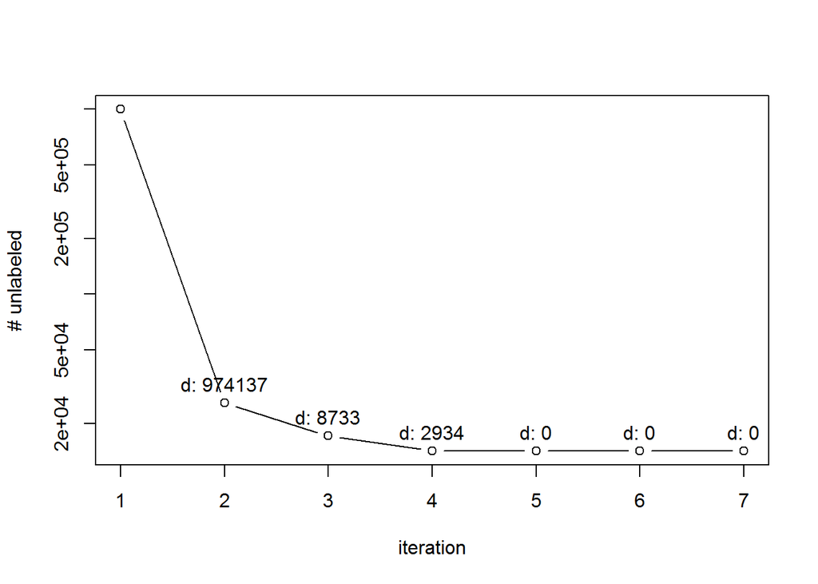

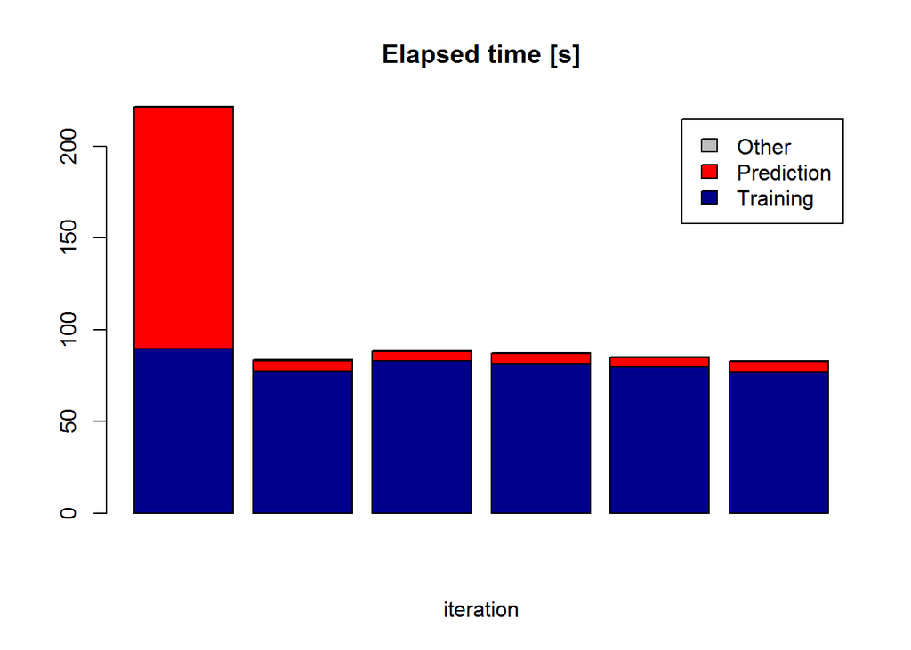

```r
plot_iocc(iocc, what="n_unlabeled")
plot_iocc(iocc, what="time")
```

```
## LOADING:  D:/github/iterOneClass/demo/results/iter-0_ini.RData
## LOADING:  D:/github/iterOneClass/demo/results/iter-1_results.RData
## CREATING rasterTiled OBJECT:  C:\Users\ben\Documents\R\win-library\3.1\iterOneClass\extdata\banana_x.tif
```

```
## LOADING:  D:/github/iterOneClass/demo/results/iter-0_ini.RData
## LOADING:  D:/github/iterOneClass/demo/results/iter-1_results.RData
## CREATING rasterTiled OBJECT:  C:\Users\ben\Documents\R\win-library\3.1\iterOneClass\extdata\banana_x.tif
```

```
## LOADING:  D:/github/iterOneClass/demo/results/iter-0_ini.RData
## LOADING:  D:/github/iterOneClass/demo/results/iter-1_results.RData
## CREATING rasterTiled OBJECT:  C:\Users\ben\Documents\R\win-library\3.1\iterOneClass\extdata\banana_x.tif
## LOADING:  D:/github/iterOneClass/demo/results/iter-0_ini.RData
## LOADING:  D:/github/iterOneClass/demo/results/iter-2_results.RData
## CREATING rasterTiled OBJECT:  C:\Users\ben\Documents\R\win-library\3.1\iterOneClass\extdata\banana_x.tif
```

```
## LOADING:  D:/github/iterOneClass/demo/results/iter-0_ini.RData
## LOADING:  D:/github/iterOneClass/demo/results/iter-2_results.RData
## CREATING rasterTiled OBJECT:  C:\Users\ben\Documents\R\win-library\3.1\iterOneClass\extdata\banana_x.tif
```

```
## LOADING:  D:/github/iterOneClass/demo/results/iter-0_ini.RData
## LOADING:  D:/github/iterOneClass/demo/results/iter-2_results.RData
## CREATING rasterTiled OBJECT:  C:\Users\ben\Documents\R\win-library\3.1\iterOneClass\extdata\banana_x.tif
## LOADING:  D:/github/iterOneClass/demo/results/iter-0_ini.RData
## LOADING:  D:/github/iterOneClass/demo/results/iter-3_results.RData
## CREATING rasterTiled OBJECT:  C:\Users\ben\Documents\R\win-library\3.1\iterOneClass\extdata\banana_x.tif
```

```
## LOADING:  D:/github/iterOneClass/demo/results/iter-0_ini.RData
## LOADING:  D:/github/iterOneClass/demo/results/iter-3_results.RData
## CREATING rasterTiled OBJECT:  C:\Users\ben\Documents\R\win-library\3.1\iterOneClass\extdata\banana_x.tif
```

```
## LOADING:  D:/github/iterOneClass/demo/results/iter-0_ini.RData
## LOADING:  D:/github/iterOneClass/demo/results/iter-3_results.RData
## CREATING rasterTiled OBJECT:  C:\Users\ben\Documents\R\win-library\3.1\iterOneClass\extdata\banana_x.tif
## LOADING:  D:/github/iterOneClass/demo/results/iter-0_ini.RData
## LOADING:  D:/github/iterOneClass/demo/results/iter-4_results.RData
## CREATING rasterTiled OBJECT:  C:\Users\ben\Documents\R\win-library\3.1\iterOneClass\extdata\banana_x.tif
```

```
## LOADING:  D:/github/iterOneClass/demo/results/iter-0_ini.RData
## LOADING:  D:/github/iterOneClass/demo/results/iter-4_results.RData
## CREATING rasterTiled OBJECT:  C:\Users\ben\Documents\R\win-library\3.1\iterOneClass\extdata\banana_x.tif
```

```
## LOADING:  D:/github/iterOneClass/demo/results/iter-0_ini.RData
## LOADING:  D:/github/iterOneClass/demo/results/iter-4_results.RData
## CREATING rasterTiled OBJECT:  C:\Users\ben\Documents\R\win-library\3.1\iterOneClass\extdata\banana_x.tif
## LOADING:  D:/github/iterOneClass/demo/results/iter-0_ini.RData
## LOADING:  D:/github/iterOneClass/demo/results/iter-5_results.RData
## CREATING rasterTiled OBJECT:  C:\Users\ben\Documents\R\win-library\3.1\iterOneClass\extdata\banana_x.tif
```

```
## LOADING:  D:/github/iterOneClass/demo/results/iter-0_ini.RData
## LOADING:  D:/github/iterOneClass/demo/results/iter-5_results.RData
## CREATING rasterTiled OBJECT:  C:\Users\ben\Documents\R\win-library\3.1\iterOneClass\extdata\banana_x.tif
```

```
## LOADING:  D:/github/iterOneClass/demo/results/iter-0_ini.RData
## LOADING:  D:/github/iterOneClass/demo/results/iter-5_results.RData
## CREATING rasterTiled OBJECT:  C:\Users\ben\Documents\R\win-library\3.1\iterOneClass\extdata\banana_x.tif
## LOADING:  D:/github/iterOneClass/demo/results/iter-0_ini.RData
## LOADING:  D:/github/iterOneClass/demo/results/iter-6_results.RData
## CREATING rasterTiled OBJECT:  C:\Users\ben\Documents\R\win-library\3.1\iterOneClass\extdata\banana_x.tif
```

```
## LOADING:  D:/github/iterOneClass/demo/results/iter-0_ini.RData
## LOADING:  D:/github/iterOneClass/demo/results/iter-6_results.RData
## CREATING rasterTiled OBJECT:  C:\Users\ben\Documents\R\win-library\3.1\iterOneClass\extdata\banana_x.tif
```

```
## LOADING:  D:/github/iterOneClass/demo/results/iter-0_ini.RData
## LOADING:  D:/github/iterOneClass/demo/results/iter-6_results.RData
## CREATING rasterTiled OBJECT:  C:\Users\ben\Documents\R\win-library\3.1\iterOneClass\extdata\banana_x.tif
```

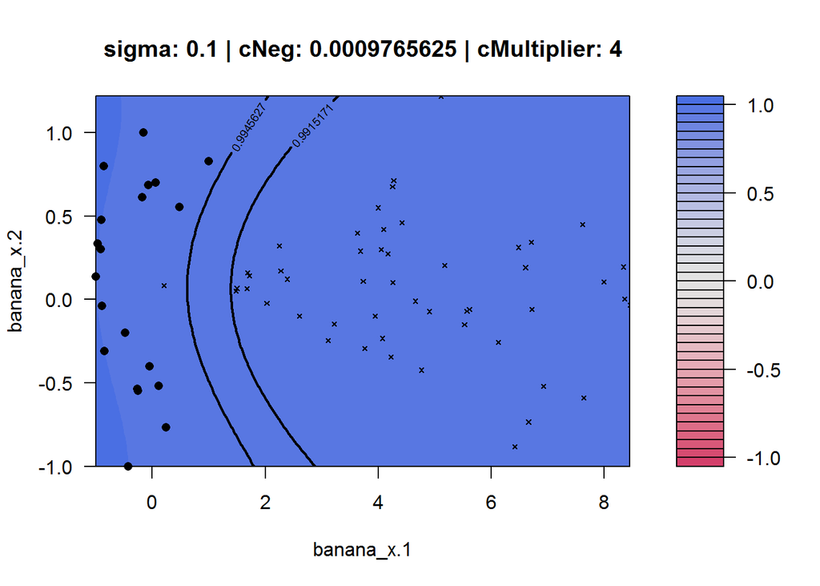

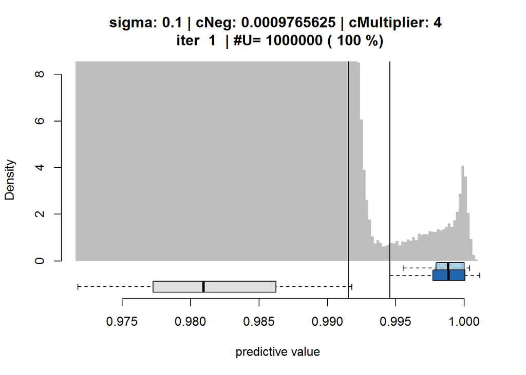

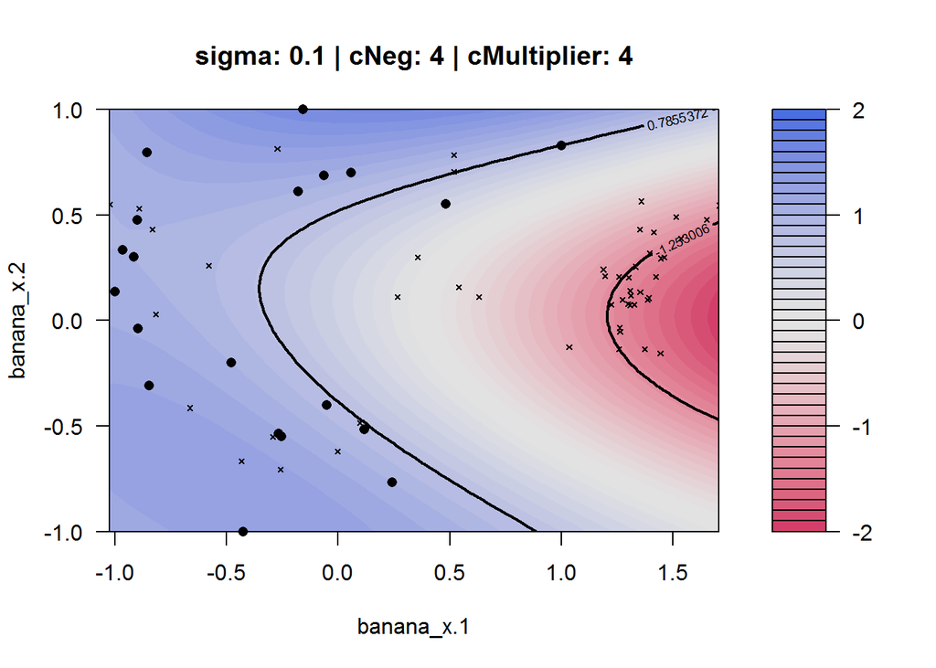

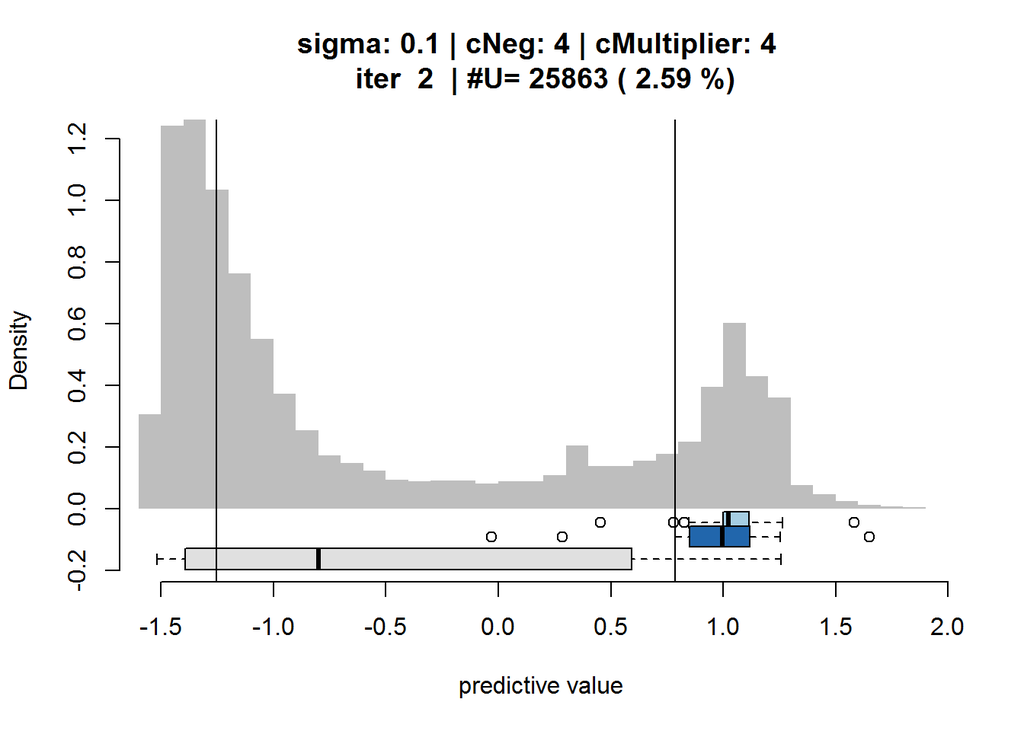

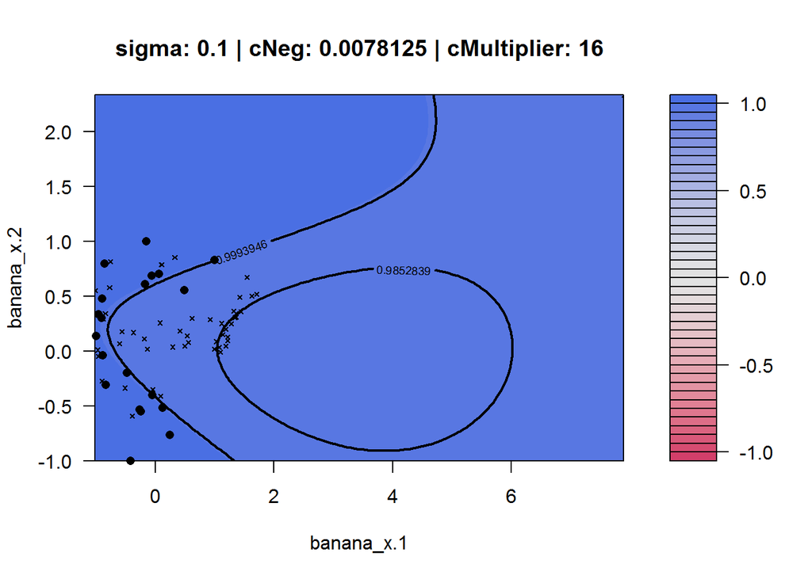

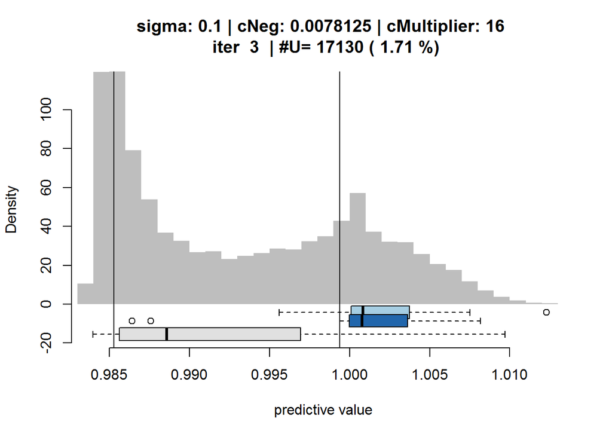

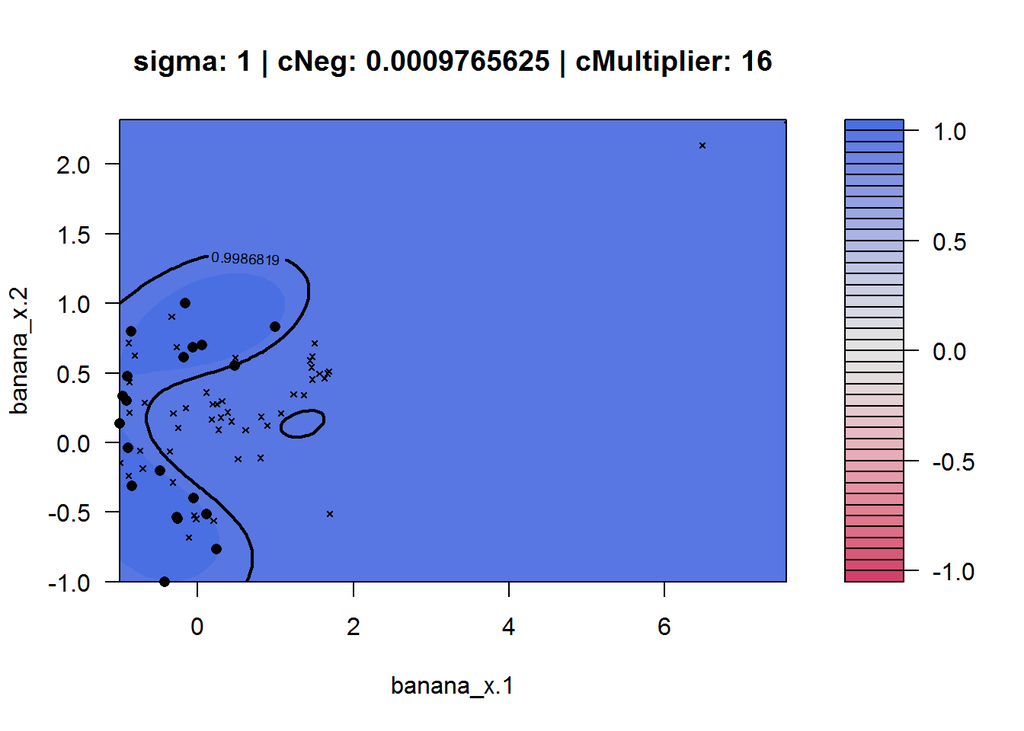

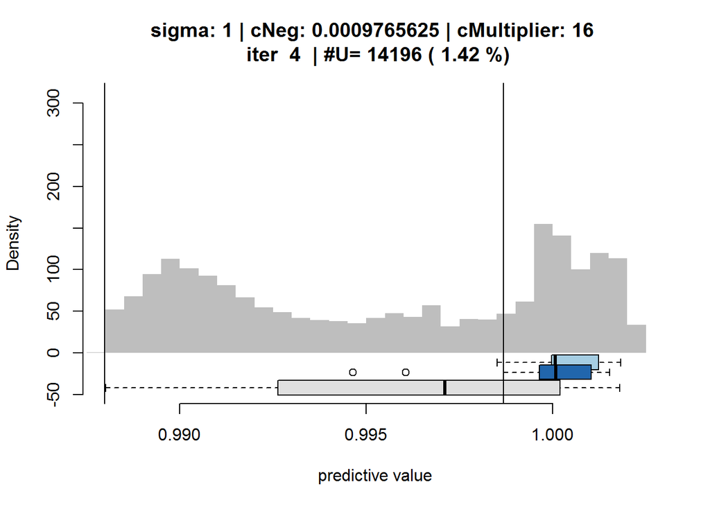

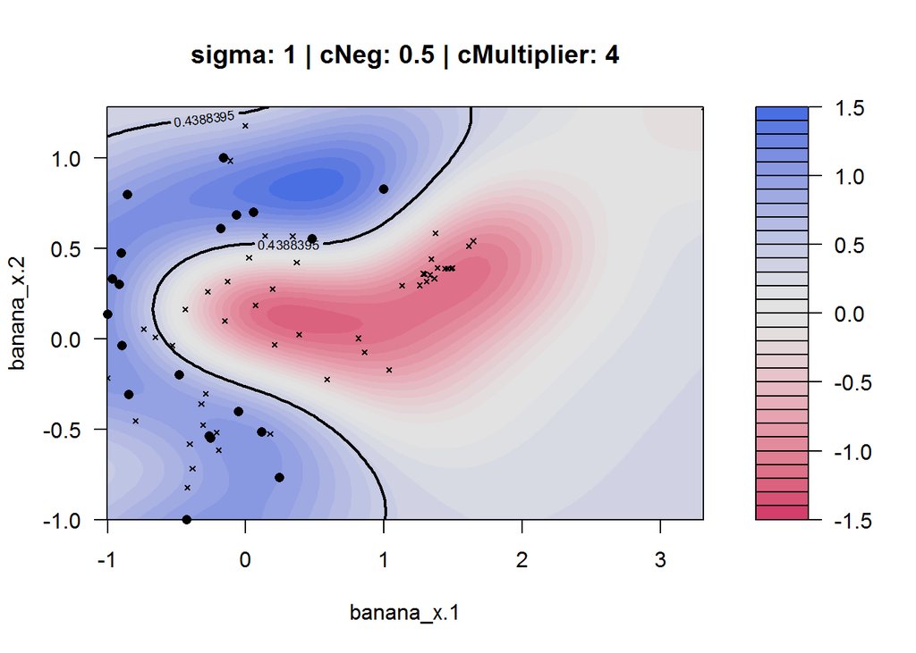

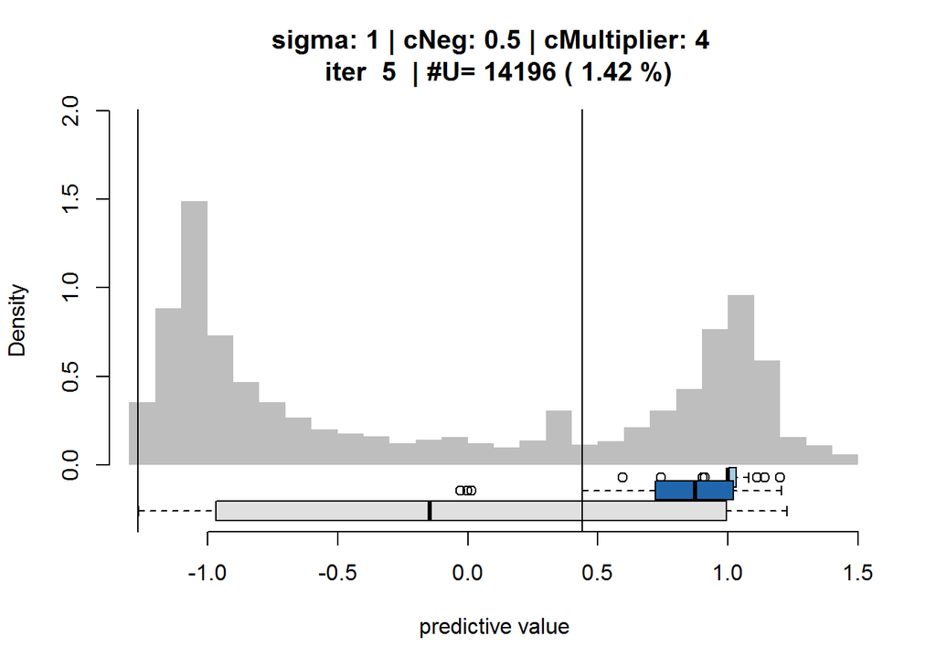

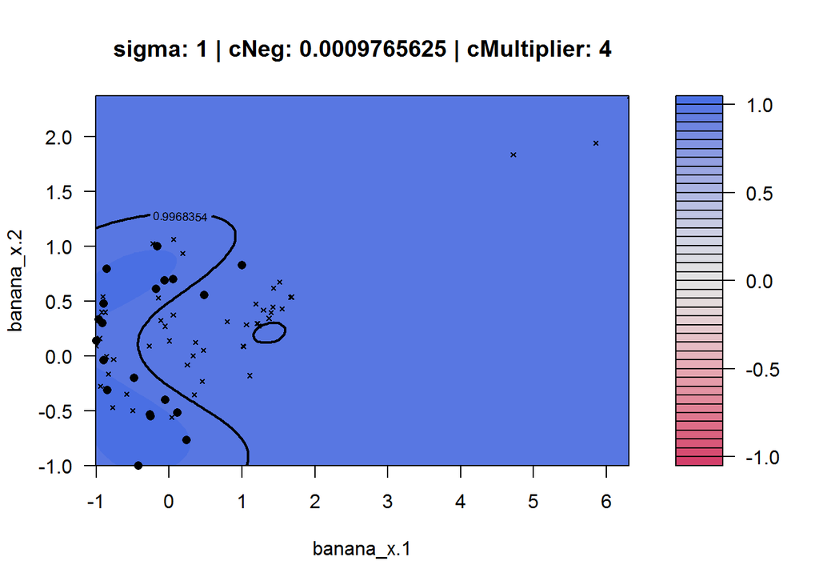

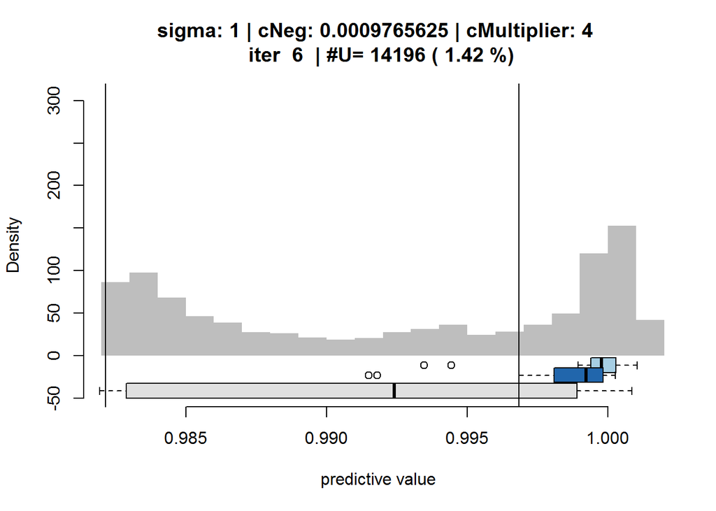

```r
for (iter in 1:6) {
  plot_iocc(baseDir, iter, what="featurespace")
  plot_iocc(baseDir, iter, what="hist")
  plot_iocc(baseDir, iter, what="eval")
}
```

## 3.3 Selection of the final model

Selection of the final model should be reviewed by an analyst familiar with the nature and challenges of one-class classification. Of course, the difficulty is to select a model without a exhaustive and representative reference data set.

In the follwing, methods are presented which facilitate the selection of the final model.

First, the diagnostic histogram plots can be analyzed and checked on their palausibility. Let us investigate the 4th iteration, i.e. the first iteration no unlabeled samples have been converted to negatives.

```r
iter <- 4
iocco <- get_ioccObj(iocc_settings$baseDir, iter=iter)
```

```
## LOADING:  D:/github/iterOneClass/demo/results/iter-0_ini.RData
## LOADING:  D:/github/iterOneClass/demo/results/iter-4_results.RData
## CREATING rasterTiled OBJECT:  C:\Users\ben\Documents\R\win-library\3.1\iterOneClass\extdata\banana_x.tif
```

Recall that the model selection so far is based on the probability of negative prediction at the lower-whisker threshold of the positive hold out predictions (`pnpAtLw`). This is not necessarily an appropriate selection criteria for the final model.

```r
iocco$model$metric
```

```
## [1] "pnpAtLw"
```

```r
modelPosition(iocco$model)
```

```
## $param
##    sigma         cNeg cMultiplier
## 65     1 0.0009765625          16
##
## $row
## [1] 65
##
## $rank
## [1] 1
```

### 3.3.1 Manual selection by investigating diagnostic histogram plots

The diagnostic histogram provide evidentce on the separability of the classes and the plausibility of the model. Let us first consider the models selected by the PU-performance metrics (`puF`and `puAuc`).

The model position of these models can be derived as follows:

```r
mp.puF <- modelPosition(iocco$model, modRank=1, by='puF')
mp.puF
```

```
## $param
##    sigma cNeg cMultiplier
## 92     1    4           4
##
## $row
## [1] 92
##
## $rank
## [1] 1
##
## $metric
## [1] "puF"
```

```r
mp.puAuc <- modelPosition(iocco$model, modRank=1, by='puAuc')
mp.puAuc
```

```
## $param
##    sigma cNeg cMultiplier
## 37   0.1   32          16
##
## $row
## [1] 37
##
## $rank
## [1] 1
##
## $metric
## [1] "puAuc"
```

With the function `get_ioccObj` an iterativeOcc object can be created for the models.

```r
cl <- makeCluster(detectCores())
registerDoParallel(cl)

modRows <- c(mp.puF$row, mp.puAuc$row)
for (modRow in modRows)
  get_ioccObj(baseDir, iter, modRow=modRow, test_set=PN)
```

```
## LOADING:  D:/github/iterOneClass/demo/results/iter-0_ini.RData
## LOADING:  D:/github/iterOneClass/demo/results/iter-4_results.RData
## CREATING rasterTiled OBJECT:  C:\Users\ben\Documents\R\win-library\3.1\iterOneClass\extdata\banana_x.tif
## UPDATING MODEL TO MODEL # 92
## Looking for predictions in  D:/github/iterOneClass/demo/results/iter-4/predU/model-092.RData
## Exists? -  TRUE
## LOADING PREDICTIONS FROM:  D:/github/iterOneClass/demo/results/iter-4/predU/model-092.RData
## LOADING:  D:/github/iterOneClass/demo/results/iter-0_ini.RData
## LOADING:  D:/github/iterOneClass/demo/results/iter-4_results.RData
## CREATING rasterTiled OBJECT:  C:\Users\ben\Documents\R\win-library\3.1\iterOneClass\extdata\banana_x.tif
## UPDATING MODEL TO MODEL # 37
## Looking for predictions in  D:/github/iterOneClass/demo/results/iter-4/predU/model-037.RData
## Exists? -  TRUE
## LOADING PREDICTIONS FROM:  D:/github/iterOneClass/demo/results/iter-4/predU/model-037.RData
```

The data is also saved in the working directory and it is now possible to plot the diagnostic histogram plot for the respective models:

```r
modRows
```

```
## [1] 92 37
```

```
## LOADING:  D:/github/iterOneClass/demo/results/iter-0_ini.RData
## LOADING:  D:/github/iterOneClass/demo/results/iter-4_results.RData
## CREATING rasterTiled OBJECT:  C:\Users\ben\Documents\R\win-library\3.1\iterOneClass\extdata\banana_x.tif
## UPDATING MODEL TO MODEL # 92
## Looking for predictions in  D:/github/iterOneClass/demo/results/iter-4/predU/model-092.RData
## Exists? -  TRUE
## LOADING PREDICTIONS FROM:  D:/github/iterOneClass/demo/results/iter-4/predU/model-092.RData
```

```
## LOADING:  D:/github/iterOneClass/demo/results/iter-0_ini.RData
## LOADING:  D:/github/iterOneClass/demo/results/iter-4_results.RData
## CREATING rasterTiled OBJECT:  C:\Users\ben\Documents\R\win-library\3.1\iterOneClass\extdata\banana_x.tif
## UPDATING MODEL TO MODEL # 92
## Looking for predictions in  D:/github/iterOneClass/demo/results/iter-4/predU/model-092.RData
## Exists? -  TRUE
## LOADING PREDICTIONS FROM:  D:/github/iterOneClass/demo/results/iter-4/predU/model-092.RData
```

```
## LOADING:  D:/github/iterOneClass/demo/results/iter-0_ini.RData
## LOADING:  D:/github/iterOneClass/demo/results/iter-4_results.RData
## CREATING rasterTiled OBJECT:  C:\Users\ben\Documents\R\win-library\3.1\iterOneClass\extdata\banana_x.tif
## UPDATING MODEL TO MODEL # 92
## Looking for predictions in  D:/github/iterOneClass/demo/results/iter-4/predU/model-092.RData
## Exists? -  TRUE
## LOADING PREDICTIONS FROM:  D:/github/iterOneClass/demo/results/iter-4/predU/model-092.RData
## LOADING:  D:/github/iterOneClass/demo/results/iter-0_ini.RData
## LOADING:  D:/github/iterOneClass/demo/results/iter-4_results.RData
## CREATING rasterTiled OBJECT:  C:\Users\ben\Documents\R\win-library\3.1\iterOneClass\extdata\banana_x.tif
## UPDATING MODEL TO MODEL # 37
## Looking for predictions in  D:/github/iterOneClass/demo/results/iter-4/predU/model-037.RData
## Exists? -  TRUE
## LOADING PREDICTIONS FROM:  D:/github/iterOneClass/demo/results/iter-4/predU/model-037.RData
```

```
## LOADING:  D:/github/iterOneClass/demo/results/iter-0_ini.RData
## LOADING:  D:/github/iterOneClass/demo/results/iter-4_results.RData
## CREATING rasterTiled OBJECT:  C:\Users\ben\Documents\R\win-library\3.1\iterOneClass\extdata\banana_x.tif
## UPDATING MODEL TO MODEL # 37
## Looking for predictions in  D:/github/iterOneClass/demo/results/iter-4/predU/model-037.RData
## Exists? -  TRUE
## LOADING PREDICTIONS FROM:  D:/github/iterOneClass/demo/results/iter-4/predU/model-037.RData
```

```
## LOADING:  D:/github/iterOneClass/demo/results/iter-0_ini.RData
## LOADING:  D:/github/iterOneClass/demo/results/iter-4_results.RData
## CREATING rasterTiled OBJECT:  C:\Users\ben\Documents\R\win-library\3.1\iterOneClass\extdata\banana_x.tif
## UPDATING MODEL TO MODEL # 37
## Looking for predictions in  D:/github/iterOneClass/demo/results/iter-4/predU/model-037.RData
## Exists? -  TRUE
## LOADING PREDICTIONS FROM:  D:/github/iterOneClass/demo/results/iter-4/predU/model-037.RData
```

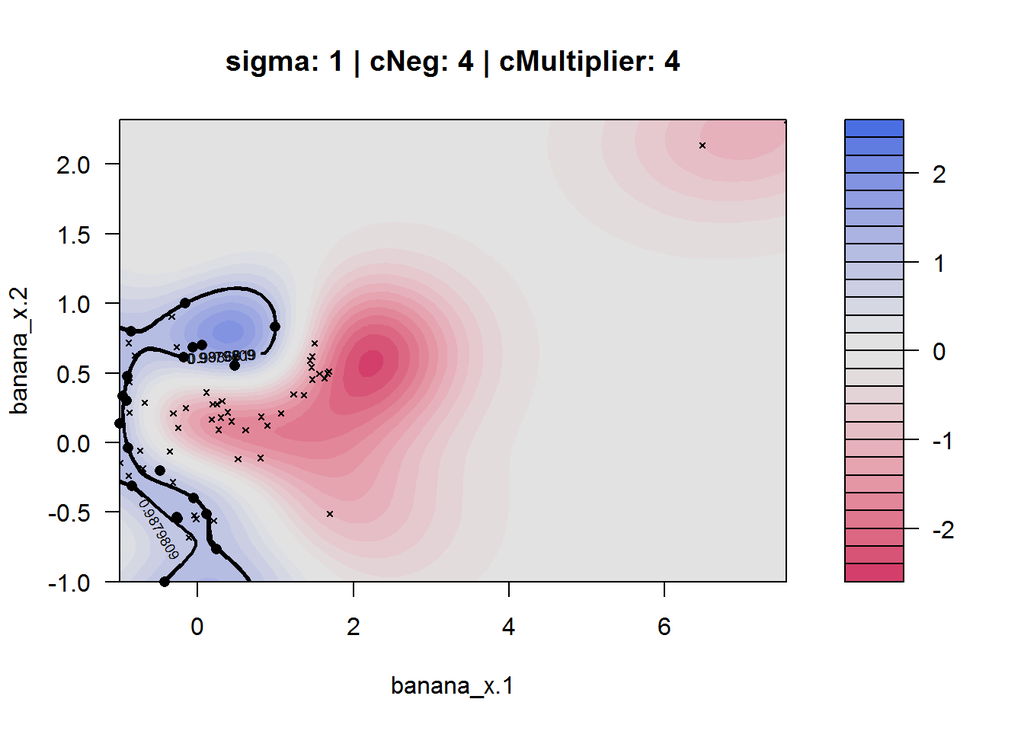

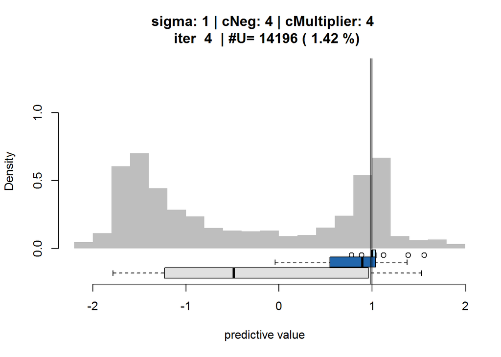

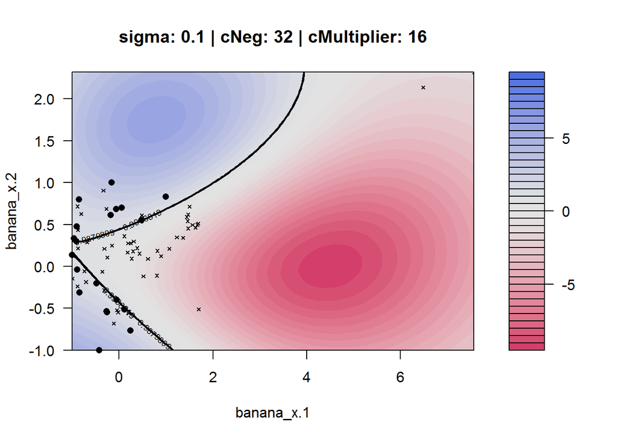

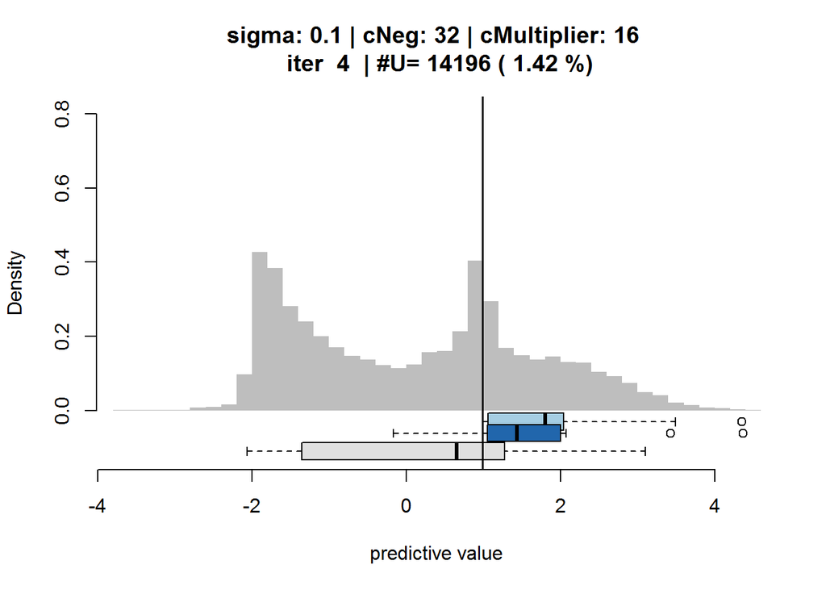

```r
for (modRow in modRows) {
  plot_iocc(baseDir, iter, what="featurespace", modRow)
  plot_iocc(baseDir, iter, what="hist", modRow)
  plot_iocc(baseDir, iter, what="eval", modRow)
}
```

The model selected by the metric `puF` (first row) seems more suitable than the model selected by the metric `puAuc` (second row). However, the two box-plots of the positive data (the lightblue beeing the predictions on the positive training data (NOT hold-out!) and the dark blue the hold-out predictions of the same data).

The fact that the hold-out predictons (dark-blue boxplot) have significant lower predictive values implies a relatively complex model. The following model illustrates a very complex model (see the feature space plot on the right) and the resulting difference between the boxplots:

```
## LOADING:  D:/github/iterOneClass/demo/results/iter-0_ini.RData
## LOADING:  D:/github/iterOneClass/demo/results/iter-4_results.RData
## CREATING rasterTiled OBJECT:  C:\Users\ben\Documents\R\win-library\3.1\iterOneClass\extdata\banana_x.tif
## UPDATING MODEL TO MODEL # 160
## Looking for predictions in  D:/github/iterOneClass/demo/results/iter-4/predU/model-160.RData
## Exists? -  FALSE
##
## PREDICTING (may take a while).
## Saving predictions as raster:  D:/github/iterOneClass/demo/results/iter-4/predU/model-160.tif
```

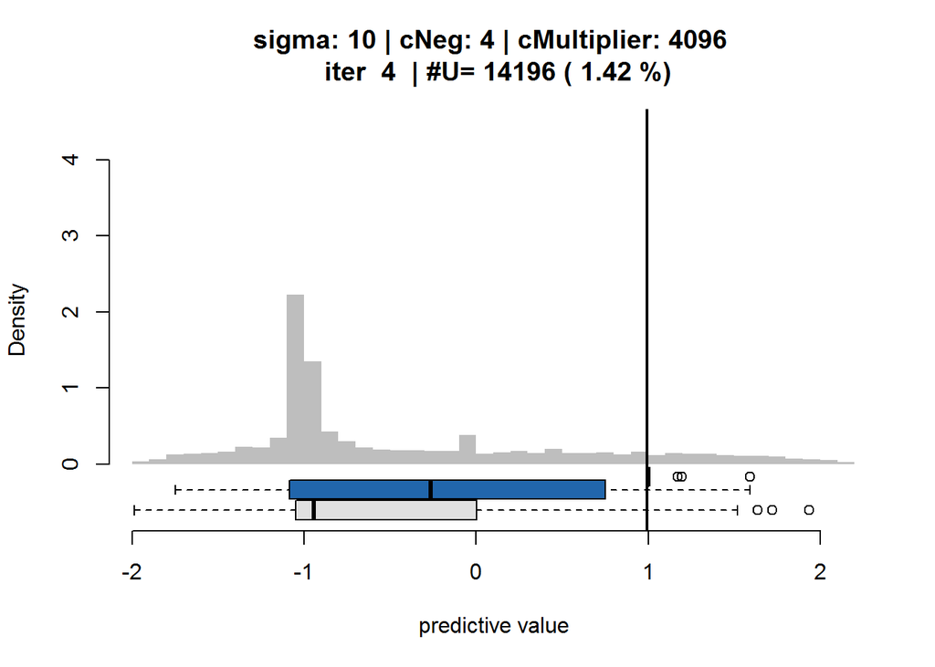

```r
plot_iocc(baseDir, iter, what="hist", modRow=160)
```

```
## LOADING:  D:/github/iterOneClass/demo/results/iter-0_ini.RData
## LOADING:  D:/github/iterOneClass/demo/results/iter-4_results.RData
## CREATING rasterTiled OBJECT:  C:\Users\ben\Documents\R\win-library\3.1\iterOneClass\extdata\banana_x.tif
## UPDATING MODEL TO MODEL # 160
## Looking for predictions in  D:/github/iterOneClass/demo/results/iter-4/predU/model-160.RData
## Exists? -  TRUE
## LOADING PREDICTIONS FROM:  D:/github/iterOneClass/demo/results/iter-4/predU/model-160.RData
```

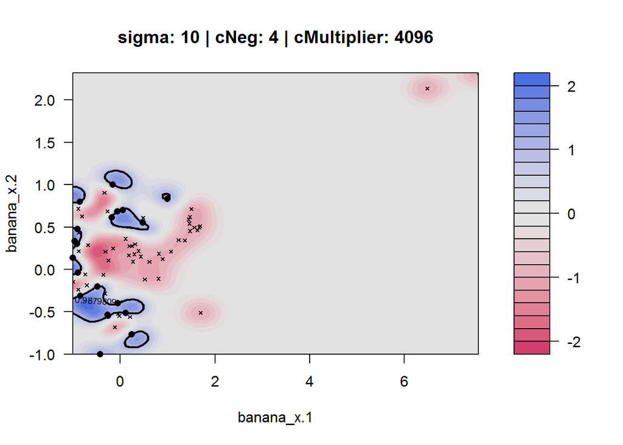

```r
plot_iocc(baseDir, iter, what="featurespace", modRow=160)
```

The `puF` model is not necessarily overfitting, nevertheless, if a model can be found which seems similarly separable (i.e. well separated histogram modes) but less complex (i.e. less difference between the blue and light-blue boxplots) it should be prefered.

In order to get a fast overview over the models we can build the histogram plots for all the models. To be faster we can build the histogram from a subset of unlabeled samples. As a major part of the unlabeled samples have already been rejected and classified as negatives a relatively small sample should be sufficient to represent well the distribution of the remaining unlabeled data.

The following function builds the diagnostic histogram plots with a subset of 5000 unlabeled samples for all models and writes the PDFs to the folder `<baseDir>/iter-4/predU-5000`:

```r
get_all_diagnostics(baseDir, iter, nUnSub=5000,
                    seed=iocc_settings$seed*2)
```

```
## LOADING:  D:/github/iterOneClass/demo/results/iter-0_ini.RData
## LOADING:  D:/github/iterOneClass/demo/results/iter-4_results.RData
## CREATING rasterTiled OBJECT:  C:\Users\ben\Documents\R\win-library\3.1\iterOneClass\extdata\banana_x.tif
## LOADING:  D:/github/iterOneClass/demo/results/iter-0_ini.RData
## LOADING:  D:/github/iterOneClass/demo/results/iter-4_results.RData
## CREATING rasterTiled OBJECT:  C:\Users\ben\Documents\R\win-library\3.1\iterOneClass\extdata\banana_x.tif
## All predictions already computed.
```

Screening these plots looking for the aforementioned simple patterns is a relatively fast task and could lead to the following alternative:

```
## LOADING:  D:/github/iterOneClass/demo/results/iter-0_ini.RData
## LOADING:  D:/github/iterOneClass/demo/results/iter-4_results.RData
## CREATING rasterTiled OBJECT:  C:\Users\ben\Documents\R\win-library\3.1\iterOneClass\extdata\banana_x.tif
## UPDATING MODEL TO MODEL # 86
## Looking for predictions in  D:/github/iterOneClass/demo/results/iter-4/predU/model-086.RData
## Exists? -  TRUE
## LOADING PREDICTIONS FROM:  D:/github/iterOneClass/demo/results/iter-4/predU/model-086.RData
```

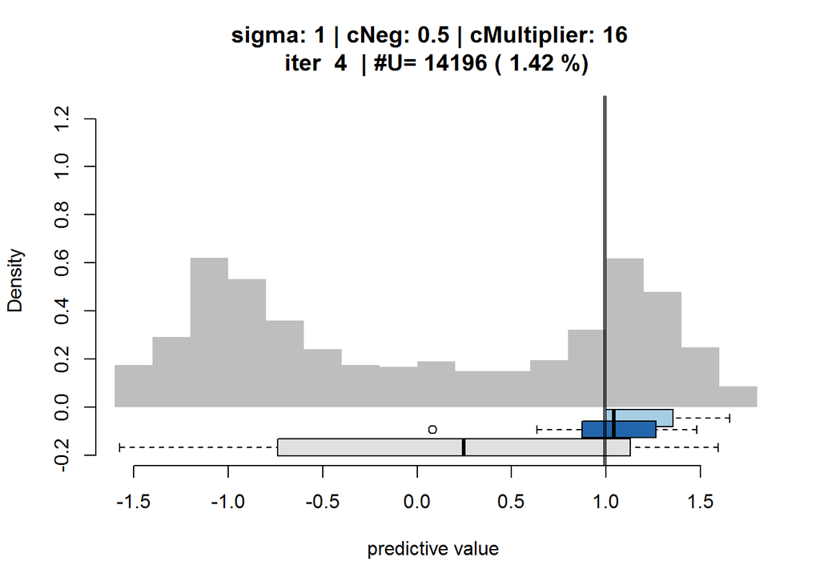

```r
plot_iocc(baseDir, iter, what="hist", modRow=86)
```

```
## LOADING:  D:/github/iterOneClass/demo/results/iter-0_ini.RData
## LOADING:  D:/github/iterOneClass/demo/results/iter-4_results.RData
## CREATING rasterTiled OBJECT:  C:\Users\ben\Documents\R\win-library\3.1\iterOneClass\extdata\banana_x.tif
## UPDATING MODEL TO MODEL # 86
## Looking for predictions in  D:/github/iterOneClass/demo/results/iter-4/predU/model-086.RData
## Exists? -  TRUE
## LOADING PREDICTIONS FROM:  D:/github/iterOneClass/demo/results/iter-4/predU/model-086.RData
```

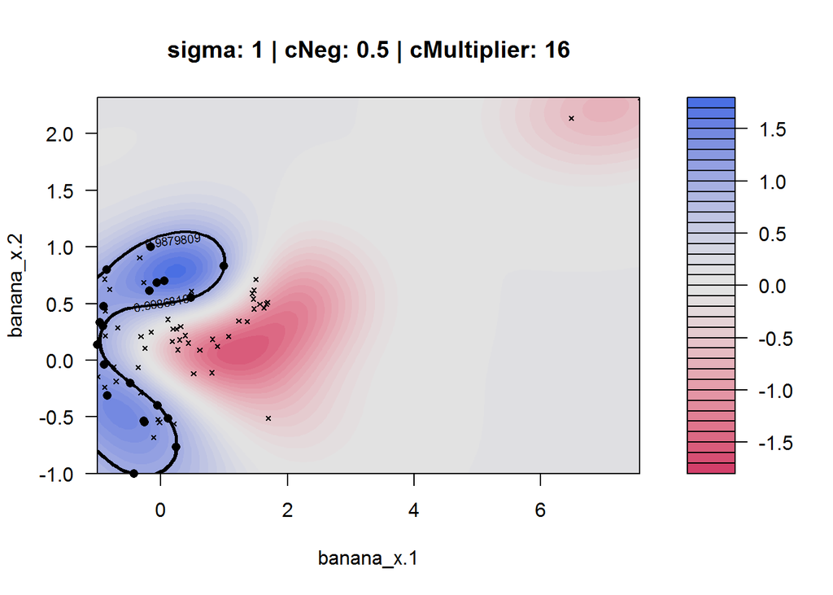

```r
plot_iocc(baseDir, iter, what="featurespace", modRow=86)
```

```r
plot_iocc(baseDir, iter, "eval")
```

```
## LOADING:  D:/github/iterOneClass/demo/results/iter-0_ini.RData
## LOADING:  D:/github/iterOneClass/demo/results/iter-4_results.RData
## CREATING rasterTiled OBJECT:  C:\Users\ben\Documents\R\win-library\3.1\iterOneClass\extdata\banana_x.tif
```